# Assignment 2

Pranavi Nallamalla

```r
library(AER)
```

```r
library(tidyverse)
library(plotly)
library(leaps)
library(corrplot)
```

```r
library(RColorBrewer)
library(psych)
```

```r
library(glmnet)
```

```r
library(formatR)
```

```r
data("CASchools")
CASchools <- CASchools[c(5:12,14)]
head(CASchools,5)
```

|  | students | teachers | calworks | lunch | computer | expenditure | income | english | math |
| --- | --- | --- | --- | --- | --- | --- | --- | --- | --- |
| 1 | 195 | 10.90 | 0.5102 | 2.0408 | 67 | 6384.911 | 22.690001 | 0.000000 | 690.0 |
| 2 | 240 | 11.15 | 15.4167 | 47.9167 | 101 | 5099.381 | 9.824000 | 4.583333 | 661.9 |
| 3 | 1550 | 82.90 | 55.0323 | 76.3226 | 169 | 5501.955 | 8.978000 | 30.000002 | 650.9 |
| 4 | 243 | 14.00 | 36.4754 | 77.0492 | 85 | 7101.831 | 8.978000 | 0.000000 | 643.5 |
| 5 | 1335 | 71.50 | 33.1086 | 78.4270 | 171 | 5235.988 | 9.080333 | 13.857677 | 639.9 |

Q: Is there a relationship between student math test scores and socioeconomic variables?

Explanation: CASchools in the AER package offers data on test scores, school demographics, and student demographic background for school districts in California. I think this way they are related.

```r
cor(CASchools)
```

```
               students    teachers    calworks       lunch    computer expenditure
students     1.00000000  0.99711606  0.09016139  0.12923399  0.92888209 -0.11228455
teachers     0.99711606  1.00000000  0.09264528  0.12429563  0.93724231 -0.09519483
calworks     0.09016139  0.09264528  1.00000000  0.73942180  0.05916015  0.06788857
lunch        0.12923399  0.12429563  0.73942180  1.00000000  0.06138610 -0.06103871
computer     0.92888209  0.93724231  0.05916015  0.06138610  1.00000000 -0.07131050
expenditure -0.11228455 -0.09519483  0.06788857 -0.06103871 -0.07131050  1.00000000
income       0.02839221  0.04300655 -0.51265102 -0.68443962  0.09434278  0.31448448
english      0.35487921  0.35142111  0.31957593  0.65306072  0.29133881 -0.07139604
math        -0.11088879 -0.10229639 -0.61769076 -0.82301452 -0.03295001  0.15498949
                 income     english        math
students     0.02839221  0.35487921 -0.11088879
teachers     0.04300655  0.35142111 -0.10229639
calworks    -0.51265102  0.31957593 -0.61769076
lunch       -0.68443962  0.65306072 -0.82301452
computer     0.09434278  0.29133881 -0.03295001
expenditure  0.31448448 -0.07139604  0.15498949
income       1.00000000 -0.30741949  0.69939814
english     -0.30741949  1.00000000 -0.56868185
math         0.69939814 -0.56868185  1.00000000
```

(i). What do you observe about the relationship between these predictors and math test scores?

Part a). Fit a linear regression model to predict math test scores on all the quantitative variables in the dataset. Also, don’t use the read test score in your regression. Discuss your results, making sure to cover the following points:

```r
lm.mod = lm(math~., data=CASchools);
summary(lm.mod)
```

```
Call:
lm(formula = math ~ ., data = CASchools)

Residuals:
     Min       1Q   Median       3Q      Max
-31.2893  -6.9982   0.2331   5.9637  30.3968

Coefficients:
              Estimate Std. Error t value Pr(>|t|)
(Intercept)  6.561e+02  4.487e+00 146.227  < 2e-16 ***
students    -6.938e-04  1.735e-03  -0.400  0.68941
teachers     5.077e-03  3.817e-02   0.133  0.89426
calworks    -1.330e-01  6.834e-02  -1.947  0.05226 .
lunch       -3.306e-01  4.273e-02  -7.735 8.05e-14 ***
computer     4.541e-03  3.266e-03   1.390  0.16519
expenditure  9.776e-04  8.645e-04   1.131  0.25877
income       6.953e-01  1.057e-01   6.576 1.47e-10 ***
english     -1.471e-01  4.097e-02  -3.591  0.00037 ***
---
Signif. codes:  0 ‘***’ 0.001 ‘**’ 0.01 ‘*’ 0.05 ‘.’ 0.1 ‘ ’ 1

Residual standard error: 9.93 on 411 degrees of freedom
Multiple R-squared:  0.725, Adjusted R-squared:  0.7197
F-statistic: 135.5 on 8 and 411 DF,  p-value: < 2.2e-16
```

(ii). Are there any insignificant variables?

Yes, there are. The insignificant variables are students,teachers,calworks, computer and expenditure.

(iii). Which predictor is explaining math scores the best?

(iv). Explain the interpretation of the coefficient on lunch in terms of the response variable.

For instance, Math explains negative correlation between the lunch and response variable.

Part b). Do you think you can fit a better model than the model in part (a)? Fit a new model that you think is a better fit for the data. What do you observe about this new model?

I think Backward Subset selection model can be used for the data. The observations are in the below output.

```r
bwd=step(lm.mod,direction="backward")
```

```
Start:  AIC=1937.14
math ~ students + teachers + calworks + lunch + computer + expenditure +
    income + english

              Df Sum of Sq   RSS    AIC
- teachers     1       1.7 40525 1935.2
- students     1      15.8 40539 1935.3
- expenditure  1     126.1 40650 1936.5
- computer     1     190.6 40714 1937.1
<none>                     40523 1937.1
- calworks     1     373.6 40897 1939.0
- english      1    1271.2 41795 1948.1
- income       1    4263.2 44787 1977.2
- lunch        1    5899.5 46423 1992.2

Step:  AIC=1935.16
math ~ students + calworks + lunch + computer + expenditure +
    income + english

              Df Sum of Sq   RSS    AIC
- expenditure  1     132.1 40657 1934.5
- students     1     178.7 40704 1935.0
<none>                     40525 1935.2
- computer     1     237.0 40762 1935.6
- calworks     1     371.9 40897 1937.0
- english      1    1270.3 41796 1946.1
- income       1    4346.5 44872 1976.0
- lunch        1    5897.9 46423 1990.2

Step:  AIC=1934.53
math ~ students + calworks + lunch + computer + income + english

           Df Sum of Sq   RSS    AIC
<none>                  40657 1934.5
- students  1     210.2 40868 1934.7
- computer  1     248.8 40906 1935.1
- calworks  1     311.4 40969 1935.7
- english   1    1301.8 41959 1945.8
- lunch     1    5782.4 46440 1988.4
- income    1    5928.7 46586 1989.7
```

```r
summary(bwd)
```

```
Call:
lm(formula = math ~ students + calworks + lunch + computer +
    income + english, data = CASchools)

Residuals:
     Min       1Q   Median       3Q      Max
-31.0549  -6.7839   0.0477   5.8737  29.9957

Coefficients:
              Estimate Std. Error t value Pr(>|t|)
(Intercept)  6.603e+02  2.475e+00 266.821  < 2e-16 ***
students    -5.051e-04  3.456e-04  -1.461 0.144717
calworks    -1.194e-01  6.716e-02  -1.778 0.076059 .
lunch       -3.257e-01  4.250e-02  -7.664 1.30e-13 ***
computer     4.815e-03  3.029e-03   1.590 0.112656
income       7.457e-01  9.609e-02   7.760 6.71e-14 ***
english     -1.488e-01  4.091e-02  -3.636 0.000311 ***
---
Signif. codes:  0 ‘***’ 0.001 ‘**’ 0.01 ‘*’ 0.05 ‘.’ 0.1 ‘ ’ 1

Residual standard error: 9.922 on 413 degrees of freedom
Multiple R-squared:  0.7241,    Adjusted R-squared:  0.7201
F-statistic: 180.7 on 6 and 413 DF,  p-value: < 2.2e-16
```

c). Write the equation for the least square fit from part b).

d). Compare the R2 and RSE for models from part (a) and (b).

R2 of Model 1 = 0.725 , R2 of Model2(backward) = 0.7241 (Model 1 is better as the R2 is greater than Model 2)

RSE of Model 1 = 9.93 , RSE of model 2(backward): 9.922 (Model 2 is better as the RSE is less than model 1)

5. Using a residuals plot for part a and part b models, state the appropriateness of using a linear model for this problem.

Model 1 Plot:

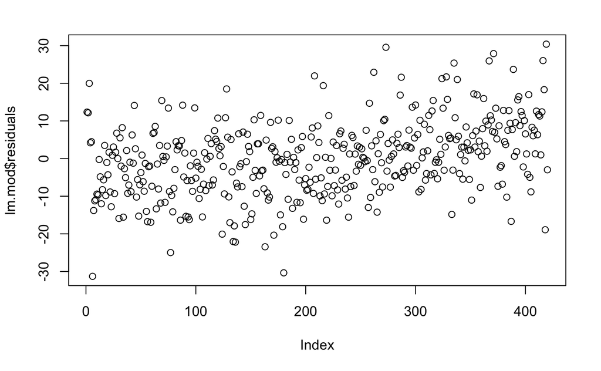

```r
plot(lm.mod$residuals)
```

Model 2 Plot:

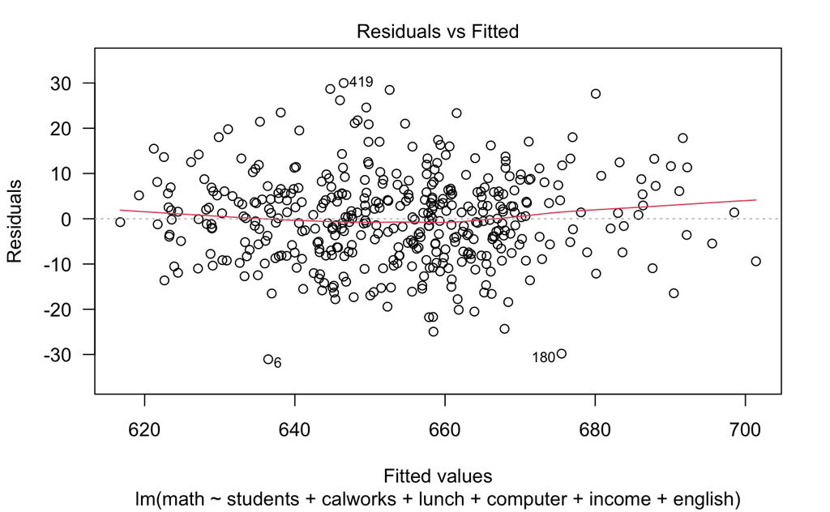

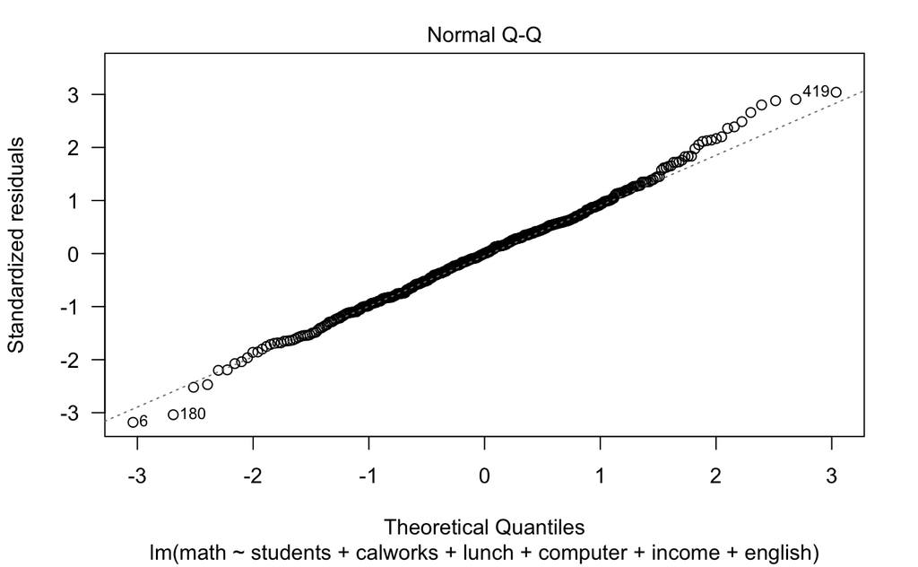

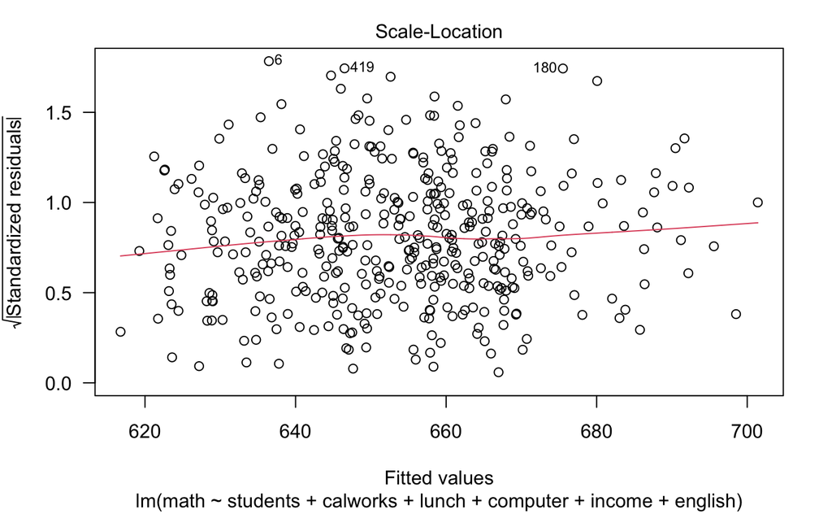

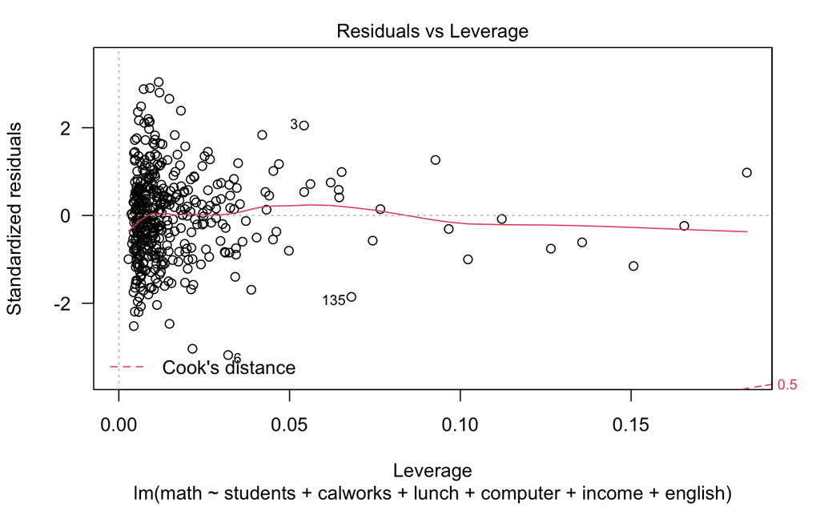

```r
plot(bwd,las=1)
```

f). Incorporate an interaction term into your multiple linear regression and respond to the following:

```r
interaction=lm(math~income*lunch,CASchools)
summary(interaction)
```

```
Call:
lm(formula = math ~ income * lunch, data = CASchools)

Residuals:
    Min      1Q  Median      3Q     Max
-33.649  -6.497  -0.073   6.062  32.841

Coefficients:
               Estimate Std. Error t value Pr(>|t|)
(Intercept)  663.059879   2.380819 278.501  < 2e-16 ***
income         0.723034   0.096719   7.476 4.59e-13 ***
lunch         -0.374784   0.041143  -9.109  < 2e-16 ***
income:lunch  -0.007328   0.003290  -2.227   0.0265 *
---
Signif. codes:  0 ‘***’ 0.001 ‘**’ 0.01 ‘*’ 0.05 ‘.’ 0.1 ‘ ’ 1

Residual standard error: 10.04 on 416 degrees of freedom
Multiple R-squared:  0.7156,    Adjusted R-squared:  0.7135
F-statistic: 348.9 on 3 and 416 DF,  p-value: < 2.2e-16
```

(i).Provide analytical justification for your interaction term.

I am choosing Lunch and income as they have good correlation with math.

(ii). Compare your results with the models from parts a) and b).

g). Fit a ‘Redge Regression’ Model for the dataset and interpret the results.

```r
x=model.matrix(math~., CASchools)[,-1]
y=CASchools$math
grid=10^seq(10,-2,length=100)
set.seed(1)
train=sample(1:nrow(x), nrow(x)/2)
test=(-train)
y.test=y[test]
ridge.mod=glmnet(x[train,],y[train],alpha=0,lambda=grid, thresh =1e-12)
set.seed (1)
cv.out=cv.glmnet(x[train ,],y[train],alpha=0)
bestlam=cv.out$lambda.min
ridge.pred=predict(ridge.mod,s=bestlam ,newx=x[test,])
out=glmnet(x,y,alpha=0,lambda=grid)
ridge.coef=predict(out,type="coefficients",s=bestlam)[1:9,]
ridge.coef
```

```
  (Intercept)      students      teachers      calworks         lunch      computer
 6.540798e+02 -1.648172e-04 -1.793546e-03 -1.984324e-01 -2.736976e-01  2.905378e-03
  expenditure        income       english
 1.086447e-03  7.125181e-01 -1.759696e-01
```

h). Fit a ‘Lasso Regression’ model for the dataset and interpret the results.

```r
lasso.mod=glmnet(x[train,], y[train], alpha=1, lambda=grid)
set.seed (1)
cv.out=cv.glmnet(x[train,],y[train],alpha=1)
bestlam=cv.out$lambda.min
lasso.pred=predict(lasso.mod,s=bestlam ,newx=x[test,])
lasso=glmnet(x,y,alpha=1,lambda=grid)
lasso.coef=predict(lasso,type="coefficients",s=bestlam)[1:9,]
lasso.coef[lasso.coef!=0]
```

```
  (Intercept)      calworks         lunch   expenditure        income       english
 6.586702e+02 -8.817604e-02 -3.457893e-01  4.944489e-04  6.960045e-01 -1.260826e-01
```

[output not shown]